```python
import pandas as pd
import numpy as np
import matplotlib.pyplot as plt

from sklearn import linear_model
from sklearn.linear_model import Ridge, RidgeCV, ElasticNet, LassoCV, LassoLarsCV
from sklearn.model_selection import cross_val_score

from sklearn.neighbors import KNeighborsRegressor
from sklearn.ensemble import RandomForestRegressor
from sklearn.svm import SVR

from sklearn.metrics import mean_squared_error
```

# Previsão de Votação de Deputados

Este notebook tem a finalidade de construir modelos preditivos de regressão em scikit learn para a predição dos votos de deputados federais considerando as eleições de 2006, 2010 e 2014.

# 1 Dados

## 1.1 Lendo os Dados

```python
eleicoes = pd.read_csv("eleicoes_2006_a_2010.csv")
df_eleicoes_2006_2010 = pd.DataFrame(eleicoes) # load the dataset as a pandas data frame
df_eleicoes_2006_2010.head(10)
#df_eleicoes.columns
```

|  | ano | sequencial_candidato | nome | uf | partido | quantidade_doacoes | quantidade_doadores | total_receita | media_receita | recursos_de_outros_candidatos/comites | ... | quantidade_despesas | quantidade_fornecedores | total_despesa | media_despesa | cargo | sexo | grau | estado_civil | ocupacao | votos |
| --- | --- | --- | --- | --- | --- | --- | --- | --- | --- | --- | --- | --- | --- | --- | --- | --- | --- | --- | --- | --- | --- |
| 0 | 2006 | 10001 | JOSÉ LUIZ NOGUEIRA DE SOUSA | AP | PT | 6 | 6 | 16600.00 | 2766.666667 | NaN | ... | 14 | 14 | 16583.60 | 1184.542857 | DEPUTADO FEDERAL | MASCULINO | ENSINO MÉDIO COMPLETO | CASADO(A) | VEREADOR | 8579 |
| 1 | 2006 | 10002 | LOIVA DE OLIVEIRA | RO | PT | 13 | 13 | 22826.00 | 1755.846154 | 6625.0 | ... | 24 | 23 | 20325.99 | 883.738696 | DEPUTADO FEDERAL | FEMININO | SUPERIOR COMPLETO | SOLTEIRO(A) | SERVIDOR PÚBLICO ESTADUAL | 2757 |
| 2 | 2006 | 10002 | MARIA DALVA DE SOUZA FIGUEIREDO | AP | PT | 17 | 16 | 148120.80 | 9257.550000 | 2250.0 | ... | 123 | 108 | 146011.70 | 1351.960185 | DEPUTADO FEDERAL | FEMININO | SUPERIOR COMPLETO | VIÚVO(A) | PEDAGOGO | 17428 |
| 3 | 2006 | 10002 | ROMALDO MILANI | MS | PRONA | 6 | 6 | 3001.12 | 500.186667 | NaN | ... | 8 | 8 | 3001.12 | 375.140000 | DEPUTADO FEDERAL | MASCULINO | ENSINO MÉDIO INCOMPLETO | CASADO(A) | MILITAR REFORMADO | 1193 |
| 4 | 2006 | 10003 | ANSELMO DE JESUS ABREU | RO | PT | 48 | 48 | NaN | NaN | NaN | ... | 133 | 120 | 116416.64 | 970.138667 | DEPUTADO FEDERAL | MASCULINO | ENSINO FUNDAMENTAL COMPLETO | CASADO(A) | DEPUTADO | 29401 |
| 5 | 2006 | 10003 | JOSÉ RODRIGUES DOS SANTOS NETO | PI | PCO | 6 | 6 | 1771.21 | 295.201667 | NaN | ... | 9 | 9 | 1771.21 | 196.801111 | DEPUTADO FEDERAL | MASCULINO | SUPERIOR COMPLETO | CASADO(A) | SERVIDOR PÚBLICO FEDERAL | 1822 |
| 6 | 2006 | 10003 | JOSÉ TOMAZ DA SILVA | MS | PRONA | 14 | 7 | 697.00 | 99.571429 | NaN | ... | 17 | 10 | 696.91 | 69.691000 | DEPUTADO FEDERAL | MASCULINO | SUPERIOR COMPLETO | CASADO(A) | MÉDICO | 317 |
| 7 | 2006 | 10003 | LUIZ CARLOS MUNHOZ MEIRA | MG | PPS | 2 | 2 | 70000.00 | 35000.000000 | NaN | ... | 332 | 278 | 66016.95 | 237.471043 | DEPUTADO FEDERAL | MASCULINO | SUPERIOR COMPLETO | CASADO(A) | SERVIDOR PÚBLICO FEDERAL | 2591 |
| 8 | 2006 | 10004 | EDILSON VEIRA ROCHA | AP | PT | 2 | 2 | 6065.00 | 3032.500000 | 6065.0 | ... | 10 | 10 | 6060.42 | 606.042000 | DEPUTADO FEDERAL | MASCULINO | ENSINO MÉDIO COMPLETO | CASADO(A) | FEIRANTE, AMBULANTE E MASCATE | 2551 |
| 9 | 2006 | 10004 | EDUARDO VALVERDE ARAÚJO ALVES | RO | PT | 68 | 65 | 105813.20 | 1627.895385 | 9575.0 | ... | 68 | 67 | 110818.20 | 1654.002985 | DEPUTADO FEDERAL | MASCULINO | SUPERIOR COMPLETO | CASADO(A) | DEPUTADO | 34631 |

10 rows × 23 columns

```python
eleicoes_2014 = pd.read_csv("eleicoes_2014.csv")
df_eleicoes_2014 = pd.DataFrame(eleicoes_2014) # load the dataset as a pandas data frame

df_eleicoes_2014.columns = ['ano', 'sequencial_candidato', 'nome', 'uf', 'partido',
       'quantidade_doacoes', 'quantidade_doadores', 'total_receita',
       'media_receita', 'recursos_de_outros_candidatos/comites',
       'recursos_de_pessoas_fisicas', 'recursos_de_pessoas_juridicas',
       'recursos_proprios', 'quantidade_despesas', 'quantidade_fornecedores',
       'total_despesa', 'media_despesa', 'cargo', 'sexo', 'grau',
       'estado_civil', 'ocupacao', 'votos']
df_eleicoes_2014.head(10)
```

|  | ano | sequencial_candidato | nome | uf | partido | quantidade_doacoes | quantidade_doadores | total_receita | media_receita | recursos_de_outros_candidatos/comites | ... | quantidade_despesas | quantidade_fornecedores | total_despesa | media_despesa | cargo | sexo | grau | estado_civil | ocupacao | votos |
| --- | --- | --- | --- | --- | --- | --- | --- | --- | --- | --- | --- | --- | --- | --- | --- | --- | --- | --- | --- | --- | --- |
| 0 | 2014 | 10000000135 | EMERSON DA SILVA SANTOS | AC | PSOL | 3 | 3 | 1580.00 | 526.666667 | NaN | ... | 3 | 3 | 1580.00 | 526.666667 | DEPUTADO FEDERAL | MASCULINO | ENSINO MÉDIO COMPLETO | SOLTEIRO(A) | CORRETOR DE IMÓVEIS, SEGUROS, TÍTULOS E VALORES | 37 |
| 1 | 2014 | 10000000142 | GERALDO SILVA DOS SANTOS | AC | PSOL | 5 | 5 | 3180.00 | 636.000000 | NaN | ... | 6 | 5 | 3130.02 | 626.004000 | DEPUTADO FEDERAL | MASCULINO | SUPERIOR COMPLETO | SOLTEIRO(A) | VIGILANTE | 383 |
| 2 | 2014 | 10000000158 | CARLOS CESAR CORREIA DE MESSIAS | AC | PSB | 40 | 38 | 333293.13 | 8770.871842 | 1923.07 | ... | 145 | 139 | 326869.78 | 2351.581151 | DEPUTADO FEDERAL | MASCULINO | ENSINO FUNDAMENTAL INCOMPLETO | CASADO(A) | OUTROS | 26448 |
| 3 | 2014 | 10000000161 | IDESIO LUIS FRANKE | AC | PT | 29 | 29 | 156719.32 | 5404.114483 | 39122.32 | ... | 136 | 121 | 241016.07 | 1991.868347 | DEPUTADO FEDERAL | MASCULINO | SUPERIOR COMPLETO | CASADO(A) | AGRÔNOMO | 9896 |
| 4 | 2014 | 10000000163 | LEONARDO CUNHA DE BRITO | AC | PT | 160 | 146 | 711083.00 | 4870.431507 | 10000.00 | ... | 518 | 354 | 567401.15 | 1602.828107 | DEPUTADO FEDERAL | MASCULINO | SUPERIOR COMPLETO | CASADO(A) | ADVOGADO | 20876 |
| 5 | 2014 | 10000000164 | MARCELO FEITOSA DE ARAÚJO | AC | PT | 4 | 3 | 23000.00 | 7666.666667 | 20000.00 | ... | 12 | 12 | 29950.00 | 2495.833333 | DEPUTADO FEDERAL | MASCULINO | ENSINO MÉDIO COMPLETO | SOLTEIRO(A) | BOMBEIRO MILITAR | 1025 |
| 6 | 2014 | 10000000166 | RAIMUNDO ANGELIM VASCONCELOS | AC | PT | 48 | 48 | 405006.67 | 8437.638958 | 24166.67 | ... | 336 | 281 | 345879.40 | 1230.887544 | DEPUTADO FEDERAL | MASCULINO | SUPERIOR COMPLETO | CASADO(A) | PROFESSOR DE ENSINO SUPERIOR | 39844 |
| 7 | 2014 | 10000000168 | RAMAO VIEIRA DE OLIVEIRA | AC | PROS | 3 | 3 | 150000.00 | 50000.000000 | 150000.00 | ... | 56 | 53 | 148903.95 | 2809.508491 | DEPUTADO FEDERAL | MASCULINO | ENSINO MÉDIO INCOMPLETO | CASADO(A) | EMPRESÁRIO | 1994 |
| 8 | 2014 | 10000000169 | REGINA AMELIA D ALENCAR LINO | AC | PTB | 15 | 13 | 460300.00 | 35407.692308 | 100000.00 | ... | 177 | 170 | 554900.36 | 3264.119765 | DEPUTADO FEDERAL | FEMININO | SUPERIOR COMPLETO | DIVORCIADO(A) | ASSISTENTE SOCIAL | 3842 |
| 9 | 2014 | 10000000170 | ROSELI COSTA | AC | PT | 13 | 13 | 66093.33 | 5084.102308 | NaN | ... | 21 | 21 | 66093.33 | 3147.301429 | DEPUTADO FEDERAL | FEMININO | SUPERIOR COMPLETO | CASADO(A) | VEREADOR | 1913 |

10 rows × 23 columns

```python
df = [df_eleicoes_2006_2010, df_eleicoes_2014]

df_eleicoes = pd.concat(df)
```

## 1.2 Distribuição das Variáveis

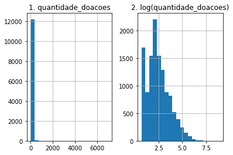

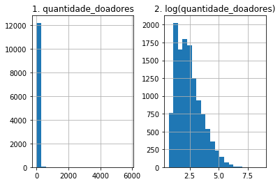

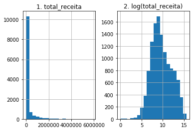

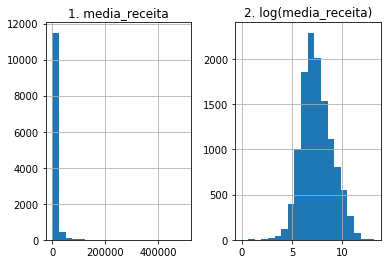

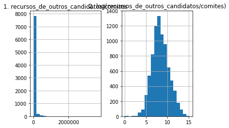

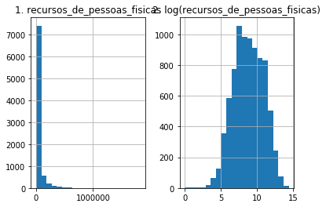

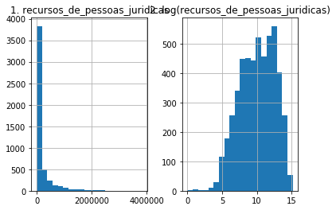

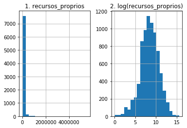

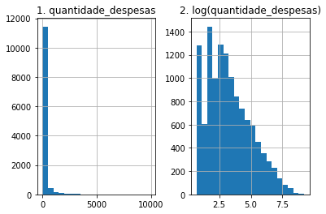

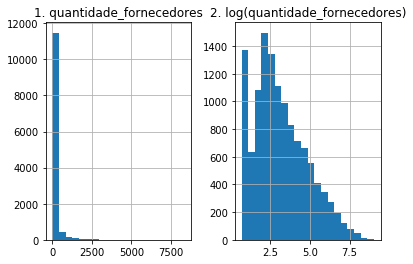

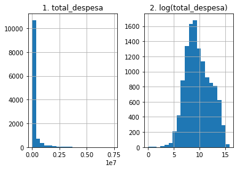

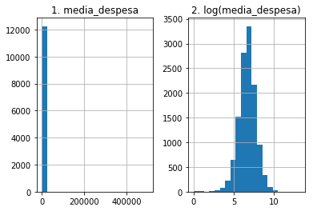

[1 more figures not shown]

```python
# function to plot a histogram of each variable
def plot_histogram(df, feature):
    # log (feature + 1) because of features with values 0
    feature = pd.DataFrame({"1. " + feature: df[feature], "2. log(" + feature + ")": np.log1p(df[feature])})
    feature.hist(bins = 20)

# function to transform skewed variables using log(feature + 1)
def transform_skewed_var(df, feature):
    df[feature] = np.log1p(df[feature])

columns = "quantidade_doacoes quantidade_doadores total_receita media_receita recursos_de_outros_candidatos/comites recursos_de_pessoas_fisicas recursos_de_pessoas_juridicas recursos_proprios quantidade_despesas quantidade_fornecedores total_despesa media_despesa votos".split()

for feature in columns:
    plot_histogram(df_eleicoes, feature)
    transform_skewed_var(df_eleicoes, feature)
```

## 1.3 Tratando Valores Ausentes

```python
df_eleicoes.isnull().any()
```

```
ano                                      False
sequencial_candidato                     False
nome                                     False
uf                                       False
partido                                  False
quantidade_doacoes                       False
quantidade_doadores                      False
total_receita                             True
media_receita                             True
recursos_de_outros_candidatos/comites     True
recursos_de_pessoas_fisicas               True
recursos_de_pessoas_juridicas             True
recursos_proprios                         True
quantidade_despesas                      False
quantidade_fornecedores                  False
total_despesa                            False
media_despesa                            False
cargo                                    False
sexo                                     False
grau                                     False
estado_civil                             False
ocupacao                                 False
votos                                    False
dtype: bool
```

```python
#filling NA's with the mean of the column:
df_eleicoes = df_eleicoes.fillna(df_eleicoes.mean())

df_eleicoes.isnull().any()
```

```
ano                                      False
sequencial_candidato                     False
nome                                     False
uf                                       False
partido                                  False
quantidade_doacoes                       False
quantidade_doadores                      False
total_receita                            False
media_receita                            False
recursos_de_outros_candidatos/comites    False
recursos_de_pessoas_fisicas              False
recursos_de_pessoas_juridicas            False
recursos_proprios                        False
quantidade_despesas                      False
quantidade_fornecedores                  False
total_despesa                            False
media_despesa                            False
cargo                                    False
sexo                                     False
grau                                     False
estado_civil                             False
ocupacao                                 False
votos                                    False
dtype: bool
```

## 1.4 Tratando Variáveis Categóricas

```python
df_eleicoes = df_eleicoes.drop("nome", 1).drop("sequencial_candidato", 1)
df_eleicoes = pd.get_dummies(df_eleicoes)

df_eleicoes.head()
```

|  | ano | quantidade_doacoes | quantidade_doadores | total_receita | media_receita | recursos_de_outros_candidatos/comites | recursos_de_pessoas_fisicas | recursos_de_pessoas_juridicas | recursos_proprios | quantidade_despesas | ... | ocupacao_TÉCNICO DE QUÍMICA | ocupacao_TÉCNICO EM AGRONOMIA E AGRIMENSURA | ocupacao_TÉCNICO EM EDIFICAÇÕES | ocupacao_TÉCNICO EM INFORMÁTICA | ocupacao_VENDEDOR DE COMÉRCIO VAREJISTA E ATACADISTA | ocupacao_VENDEDOR PRACISTA, REPRESENTANTE, CAIXEIRO-VIAJANTE E ASSEMELHADOS | ocupacao_VEREADOR | ocupacao_VETERINÁRIO | ocupacao_VIGILANTE | ocupacao_ZOOTECNISTA |
| --- | --- | --- | --- | --- | --- | --- | --- | --- | --- | --- | --- | --- | --- | --- | --- | --- | --- | --- | --- | --- | --- |
| 0 | 2006 | 1.945910 | 1.945910 | 9.717218 | 7.925760 | 8.370968 | 9.105091 | 8.748464 | 7.170888 | 2.708050 | ... | 0 | 0 | 0 | 0 | 0 | 0 | 1 | 0 | 0 | 0 |
| 1 | 2006 | 2.639057 | 2.639057 | 10.035699 | 7.471276 | 8.798757 | 9.615872 | 6.908755 | 5.308268 | 3.218876 | ... | 0 | 0 | 0 | 0 | 0 | 0 | 0 | 0 | 0 | 0 |
| 2 | 2006 | 2.890372 | 2.833213 | 11.905790 | 9.133303 | 7.719130 | 10.438547 | 11.038461 | 10.993748 | 4.820282 | ... | 0 | 0 | 0 | 0 | 0 | 0 | 0 | 0 | 0 | 0 |
| 3 | 2006 | 1.945910 | 1.945910 | 8.007074 | 6.216979 | 8.370968 | 7.048386 | 7.004991 | 6.621406 | 2.197225 | ... | 0 | 0 | 0 | 0 | 0 | 0 | 0 | 0 | 0 | 0 |
| 4 | 2006 | 3.891820 | 3.891820 | 9.670482 | 7.468538 | 8.370968 | 10.837206 | 10.021113 | 11.141035 | 4.897840 | ... | 0 | 0 | 0 | 0 | 0 | 0 | 0 | 0 | 0 | 0 |

5 rows × 284 columns

## 1.5 Divisão dos Dados em Treino, Validação e Teste

```python
df_train_2006 = df_eleicoes.loc[df_eleicoes["ano"] == 2006]
Y_train_2006 = df_train_2006.votos
X_train_2006 = df_train_2006.drop("votos", 1)
print(X_train_2006.shape)
print(Y_train_2006.shape)

df_validation_2010 = df_eleicoes.loc[df_eleicoes["ano"] == 2010]
Y_validation_2010 = df_validation_2010.votos
X_validation_2010 = df_validation_2010.drop("votos", 1)
print(X_validation_2010.shape)
print(Y_validation_2010.shape)
```

```
(3388, 283)
(3388,)
(3942, 283)
(3942,)
```

```python
df_train_validation = [df_train_2006, df_validation_2010]
df_train_2006_2010 = pd.concat(df_train_validation)
Y_train_2006_2010 = df_train_2006_2010.votos
X_train_2006_2010 = df_train_2006_2010.drop("votos", 1)
print(X_train_2006_2010.shape)
print(Y_train_2006_2010.shape)
```

```
(7330, 283)
(7330,)
```

```python
df_test_2014 = df_eleicoes.loc[df_eleicoes["ano"] == 2014]
Y_test_2014 = df_test_2014.votos
X_test_2014 = df_test_2014.drop("votos", 1)
print(X_test_2014.shape)
print(Y_test_2014.shape)
```

```
(4936, 283)
(4936,)
```

# 2 Funções

Função para plotar os resíduos

```python
def plot_residuals_vs_fit(X,Y, model, title):
    y_pred = model.predict(X)
    res = Y - y_pred
    plt.rcParams['figure.figsize'] = (8.0, 8.0)
    plt.plot(y_pred,res,'k.',color='blue',)
    plt.axhline(y=0., color='r', linestyle='-')
    plt.title(title)
    plt.xlabel("predictions")
    plt.ylabel("residuals")
```

Função para retornar os valores de rmse da validação cruzada

```python
## function to get cross validation rmse
def rmse_cv(model):
    rmse = np.sqrt(-cross_val_score(model, X_train_2006, Y_train_2006, scoring="neg_mean_squared_error", cv = 5))
    return(rmse)
```

# 3 Modelos

## 3.1 Modelo Sem Regularização

```python
linear_reg = linear_model.LinearRegression() # this creates a linear regression object
linear_reg.fit(X_train_2006,Y_train_2006) #this function fits a linear model

print("error (R²): ", linear_reg.score(X_validation_2010,Y_validation_2010))
```

```
error (R²):  -4.4346177960723907e+18
```

## 3.2 Ridge

A regressão ridge se propõe a evitar o overfitting adicionando um custo ao RSS (dos mínimos quadrados) que depende da norma L2 dos coeficientes $\|w\|$ (ou seja da magnitude dos coeficientes). O resultado é a penalização de ajustes com coeficientes muito grandes. A força dessa penalidade é controlada por um parâmetro lambda (aqui chamado "alpha").

### 3.2.1 Ridge + Validação Cruzada

```python
alphas = [0.05, 0.1, 0.3, 1, 3, 5, 10, 15, 20, 25, 30, 35, 40, 45, 50, 60, 75]
cv_ridge = [rmse_cv(Ridge(alpha = alpha)).mean()
            for alpha in alphas]
cv_ridge = pd.Series(cv_ridge, index = alphas)
```

```
Best alpha:  10.0
Best RMSE:  0.9475233670086846
```

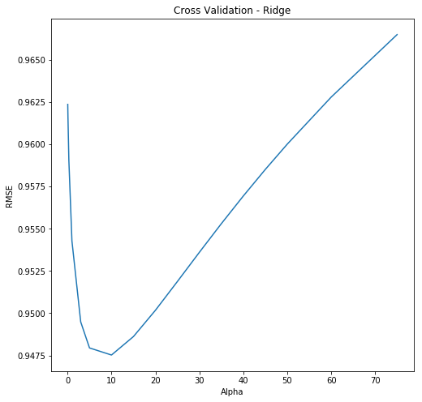

```python
cv_ridge.plot(title = "Cross Validation - Ridge")
plt.xlabel("Alpha")
plt.ylabel("RMSE")

best_alpha_ridge = cv_ridge.idxmin()

print("Best alpha: ", best_alpha_ridge)
best_rmse_ridge = cv_ridge.min()
print("Best RMSE: ", best_rmse_ridge)
```

### 3.2.2 Melhor Modelo Ridge + Gráfico de Resíduos

```
R²:  0.711592311505246
```

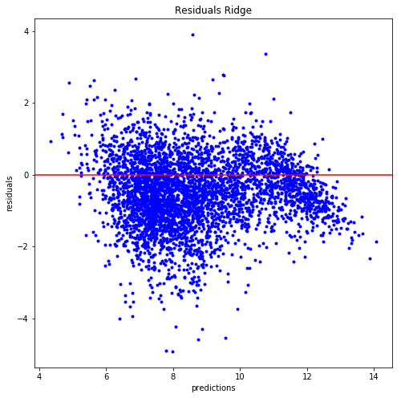

```python
best_ridge = Ridge(alpha = best_alpha_ridge)
best_ridge.fit(X_train_2006, Y_train_2006)

score_ridge = best_ridge.score(X_validation_2010, Y_validation_2010)
print("R²: ", score_ridge)

plot_residuals_vs_fit(X_validation_2010, Y_validation_2010, best_ridge, "Residuals Ridge")
```

## 3.3 Lasso

A regressão Lasso, ao mesmo tempo, encolhe a magnitude dos coeficientes para evitar o overfitting e realiza implicitamente seleção de característcas igualando alguns atributos a zero (para lambdas, aqui chamados "alpha", suficientemente grandes). Em particular, o Lasso adiciona ao RSS o custo $\|w\|$.

### 3.3.1 Lasso + Validação Cruzada

```python
alphas = [0.005, 0.0005, 0.0004, 0.0003, 0.0002, 0.0001, 0.00005]
cv_lasso = [rmse_cv(linear_model.Lasso(alpha = alpha, max_iter = 10000)).mean()
            for alpha in alphas]

cv_lasso = pd.Series(cv_lasso, index = alphas)
```

```
Best alpha:  0.0005
Best RMSE:  0.9506531498306632
```

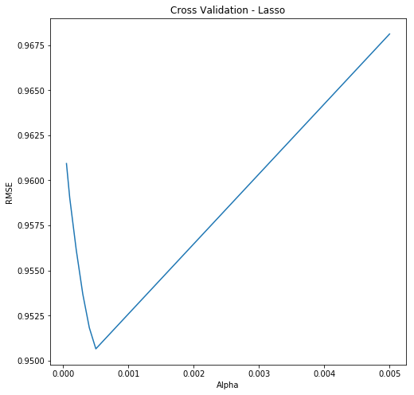

```python
cv_lasso.plot(title = "Cross Validation - Lasso")
plt.xlabel("Alpha")
plt.ylabel("RMSE")

best_alpha_lasso =  cv_lasso.idxmin()
print("Best alpha: ",  best_alpha_lasso)
best_rmse_lasso = cv_lasso.min()
print("Best RMSE: ", best_rmse_lasso)
```

### 3.3.2 Melhor Modelo Lasso + Gráfico de Resíduos

```
R²:  0.7117313970959211
```

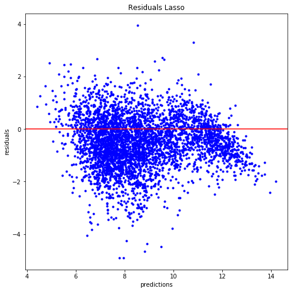

```python
best_lasso = linear_model.Lasso(alpha = best_alpha_lasso, max_iter = 10000)
best_lasso.fit(X_train_2006, Y_train_2006)

score_lasso = best_lasso.score(X_validation_2010, Y_validation_2010)
print("R²: ", score_lasso)
plot_residuals_vs_fit(X_validation_2010, Y_validation_2010, best_lasso, "Residuals Lasso")
```

### 3.3.3 Parâmetros

```python
coef = pd.Series(best_lasso.coef_, index = X_train_2006.columns)
print("Lasso picked " + str(sum(coef != 0)) + " variables and eliminated the other " +  str(sum(coef == 0)) + " variables")
```

```
Lasso picked 128 variables and eliminated the other 155 variables
```

```
Text(0.5,1,'Importance Of Coefficients in the Lasso Model')
```

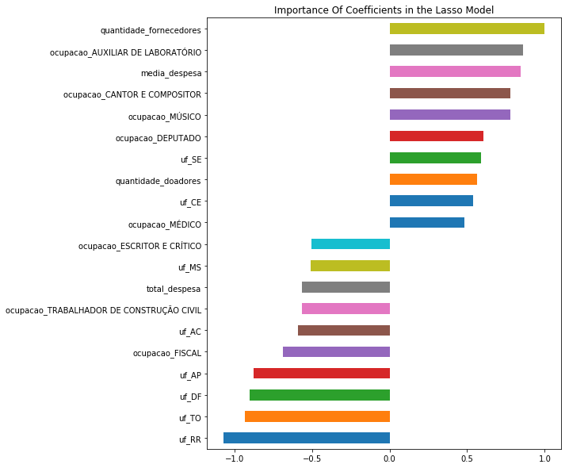

```python
imp_coef = pd.concat([coef.sort_values().head(10),
                     coef.sort_values().tail(10)])

plt.rcParams['figure.figsize'] = (8.0, 10.0)
imp_coef.plot(kind = "barh")
plt.title("Importance Of Coefficients in the Lasso Model")
```

## 3.4 KNN

KNN (K nearest neighbors) regression é um algoritmo que armazena todos os casos disponíveis e prevê o alvo numérico com base em uma medida de similaridade (por exemplo, funções de distância).

### 3.4.1 KNN + Validação Cruzada

```python
neighbors = [1,2,3,4,5,10,12,14,16,20,22,24,26,28,29,30,35,40,42,45,47,50,55,60]
cv_knn = [rmse_cv(KNeighborsRegressor(n_neighbors = neighbor)).mean()
            for neighbor in neighbors]

cv_knn = pd.Series(cv_knn, index = neighbors)
```

```
Best neighbor:  35
Best RMSE:  0.9664271214671396
```

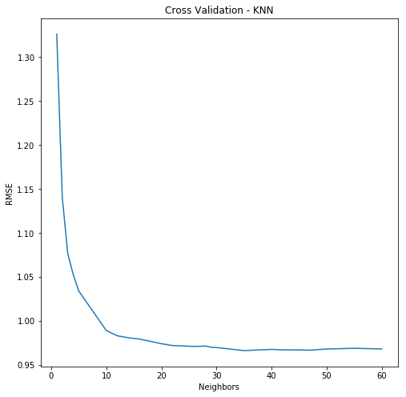

```python
cv_knn.plot(title = "Cross Validation - KNN")
plt.xlabel("Neighbors")
plt.ylabel("RMSE")

best_n_neighbor =  cv_knn.idxmin()
print("Best neighbor: ",  best_n_neighbor)
best_rmse_knn = cv_knn.min()
print("Best RMSE: ", best_rmse_knn)
```

### 3.4.2 Melhor Modelo KNN + Gráfico de Resíduos

```
R²:  0.7103074364949679
```

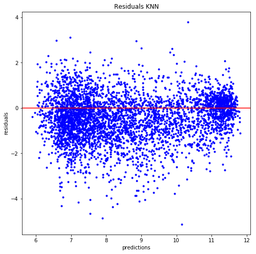

```python
best_knn = KNeighborsRegressor(n_neighbors = best_n_neighbor)
best_knn.fit(X_train_2006, Y_train_2006)

score_knn = best_knn.score(X_validation_2010, Y_validation_2010)
print("R²: ", score_knn)

plot_residuals_vs_fit(X_validation_2010, Y_validation_2010, best_knn, "Residuals KNN")
```

## 3.5 Random Forest

Random Forest regressor é um modelo de aprendizado supervisionado que constrói uma multiplicidade de árvores de decisão no momento do treinamento e gera a previsão da média das árvores individuais.

### 3.5.1 Random Forest + Validação Cruzada

```
Best number of estimators:  200
Best RMSE:  0.9403374140089813
```

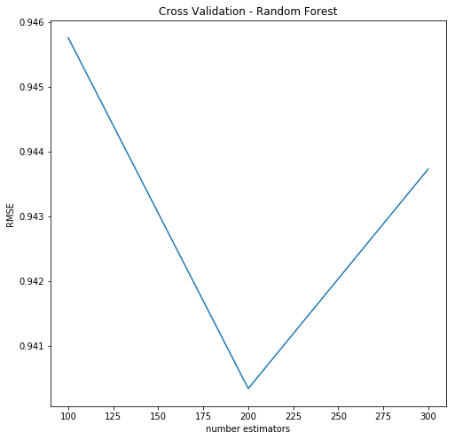

```python
n_estimators_list = [100,200,300]

cv_random_forest = [rmse_cv(RandomForestRegressor(n_estimators = n_estimators)).mean()
            for n_estimators in n_estimators_list]

csv_random_forest = pd.Series(cv_random_forest, index = n_estimators_list)

csv_random_forest.plot(title = "Cross Validation - Random Forest")
plt.xlabel("number estimators")
plt.ylabel("RMSE")


best_n_estimators =  csv_random_forest.idxmin()
print("Best number of estimators: ",  best_n_estimators)
best_rmse_rf = csv_random_forest.min()
print("Best RMSE: ", best_rmse_rf)
```

### 3.5.2 Melhor Modelo Random Forest + Gráfico de Resíduos

```
R²:  0.7047204187389279
```

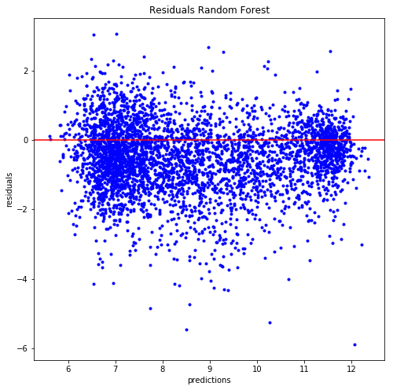

```python
best_random_forest = RandomForestRegressor(n_estimators = best_n_estimators)
best_random_forest.fit(X_train_2006, Y_train_2006)

score_rf = best_random_forest.score(X_validation_2010, Y_validation_2010)
print("R²: ", score_rf)

plot_residuals_vs_fit(X_validation_2010, Y_validation_2010, best_random_forest, "Residuals Random Forest")
```

## 3.6 SVR

SVR (Epsilon-Support Vector Regression). O modelo produzido pelo SVR depende de um subconjunto dos dados de treinamento, porque a função de custo para construir o modelo ignora quaisquer dados de treinamento próximos à previsão do modelo.

### 3.6.1 SVR + Validação Cruzada

O SVR possui diversos parâmetros, mas resolvi variar apenas o **epsilon**. Esse parâmetro especifica o tubo-épsilon dentro do qual nenhuma penalidade é associada na função de perda de treinamento com pontos previstos dentro de uma distância epsilon do valor real.

O valor default de epsilon é 0.1. Este também foi o melhor valor encontrado na validação cruzada.

[output not shown]

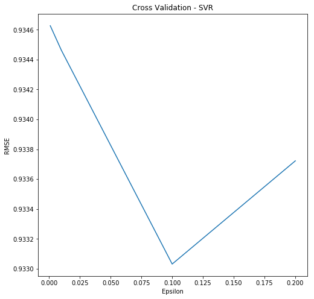

```python
epsilons = [0.001, 0.01, 0.1, 0.2]

cv_svr = [rmse_cv(SVR(epsilon = epsilon)).mean()
            for epsilon in epsilons]

cv_svr = pd.Series(cv_svr, index = epsilons)

cv_svr.plot(title = "Cross Validation - SVR")
plt.xlabel("Epsilon")
plt.ylabel("RMSE")


best_epsilon =  cv_svr.idxmin()
print("Best epsilon: ",  best_epsilon)
best_rmse_svr = cv_svr.min()
print("Best RMSE: ", best_rmse_knn)
```

### 3.6.2 Melhor Modelo SVR + Gráfico de Resíduos

```
R²:  0.7114159303002718
```

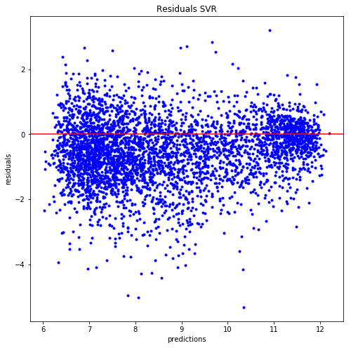

```python
best_svr = SVR(epsilon = best_epsilon)
best_svr.fit(X_train_2006, Y_train_2006)

score_svr = best_svr.score(X_validation_2010, Y_validation_2010)
print("R²: ", score_svr)
plot_residuals_vs_fit(X_validation_2010, Y_validation_2010, best_svr, "Residuals SVR")
```

## 3.7 Resumo dos Resultados

Abaixo podemos ver um resumo dos valores de RMSE e R² retornados por cada modelo.

```python
print('RIDGE: RMSE', best_rmse_ridge, ' - R² ', score_ridge)
print('-' * 55)
print('LASSO: RMSE', best_rmse_lasso, ' - R² ', score_lasso)
print('-' * 55)
print('KNN: RMSE', best_rmse_knn, ' - R² ', score_knn)
print('-' * 55)
print('RF: RMSE', best_rmse_rf, ' - R² ', score_rf)
print('-' * 55)
print('SVR: RMSE', best_rmse_svr, ' - R² ', score_svr)
print('-' * 55)
```

```
RIDGE: RMSE 0.9475233670086846  - R²  0.711592311505246
-------------------------------------------------------
LASSO: RMSE 0.9506531498306632  - R²  0.7117313970959211
-------------------------------------------------------
KNN: RMSE 0.9664271214671396  - R²  0.7103074364949679
-------------------------------------------------------
RF: RMSE 0.9403374140089813  - R²  0.7047204187389279
-------------------------------------------------------
SVR: RMSE 0.9330314696412796  - R²  0.7114159303002718
-------------------------------------------------------
```

# 4 Usando os melhores modelos

## 4.1 Testando o melhor Ridge

```python
best_ridge.fit(X_train_2006_2010, Y_train_2006_2010)
Y_pred_ridge = best_ridge.predict(X_test_2014)

mse_ridge = mean_squared_error(Y_test_2014, Y_pred_ridge)
rmse_ridge = np.sqrt(mse_ridge)
score_ridge = best_ridge.score(X_test_2014, Y_test_2014)

print("R²: ", score_ridge)
print("MSE: ", mse_ridge)
print("RMSE: ", rmse_ridge)
```

```
R²:  0.5633738974503608
MSE:  2.852413406611211
RMSE:  1.6889089397037398
```

## 4.2 Testando o melhor Lasso

```python
best_lasso.fit(X_train_2006_2010, Y_train_2006_2010)
Y_pred_lasso = best_lasso.predict(X_test_2014)

mse_lasso = mean_squared_error(Y_test_2014, Y_pred_lasso)
rmse_lasso = np.sqrt(mse_lasso)
score_lasso = best_lasso.score(X_test_2014, Y_test_2014)

print("R²: ", score_lasso)
print("MSE: ", mse_lasso)
print("RMSE: ", rmse_lasso)
```

```
R²:  0.5636544527144243
MSE:  2.8505805807864677
RMSE:  1.6883662460457054
```

## 4.3 Testando o melhor KNN

```python
best_knn.fit(X_train_2006_2010, Y_train_2006_2010)

Y_pred_knn = best_knn.predict(X_test_2014)

mse_knn = mean_squared_error(Y_test_2014, Y_pred_knn)
rmse_knn = np.sqrt(mse_knn)
score_knn = best_knn.score(X_test_2014, Y_test_2014)

print("R²: ", score_knn)
print("MSE: ", mse_knn)
print("RMSE: ", rmse_knn)
```

```
R²:  0.5122064913311187
MSE:  3.1866824627756984
RMSE:  1.785128136234399
```

## 4.4 Testando o melhor Random Forest

```python
best_random_forest.fit(X_train_2006_2010, Y_train_2006_2010)

Y_pred_random_forest = best_random_forest.predict(X_test_2014)

mse_random_forest = mean_squared_error(Y_test_2014, Y_pred_random_forest)
rmse_random_forest = np.sqrt(mse_random_forest)
score_random_forest = best_random_forest.score(X_test_2014, Y_test_2014)

print("R²: ", score_random_forest)
print("MSE: ", mse_random_forest)
print("RMSE: ", rmse_random_forest)
```

```
R²:  0.5188559677226556
MSE:  3.143242422211453
RMSE:  1.7729191809587521
```

## 4.5 Testando o SVR

```python
best_svr.fit(X_train_2006_2010, Y_train_2006_2010)

Y_pred_svr = best_svr.predict(X_test_2014)

mse_svr = mean_squared_error(Y_test_2014, Y_pred_svr)
rmse_svr = np.sqrt(mse_svr)
score_svr = best_svr.score(X_test_2014, Y_test_2014)

print("R²: ", score_svr)
print("MSE: ", mse_svr)
print("RMSE: ", rmse_svr)
```

```
R²:  0.5546191348598022
MSE:  2.9096069688815023
RMSE:  1.705757007572152
```

# 5 Conclusões

Nos gráficos abaixo é possível visualizar os resultados dos modelos em termos de RMSE e de R² para os dados de 2014.

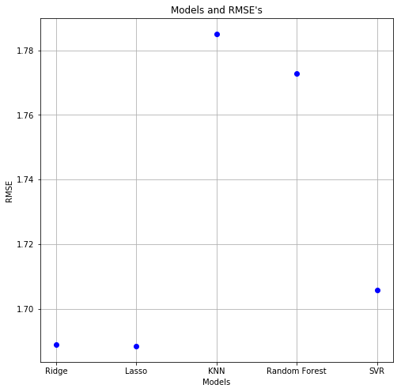

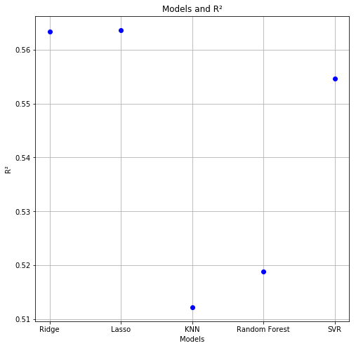

```python
plt.plot(["Ridge","Lasso","KNN","Random Forest", "SVR"],
         [rmse_ridge,rmse_lasso,rmse_knn,rmse_random_forest, rmse_svr],
         'ro', color="blue")
plt.grid(True)
plt.xlabel("Models")
plt.ylabel("RMSE")
plt.title("Models and RMSE's")
plt.show()

plt.plot(["Ridge","Lasso","KNN","Random Forest", "SVR"],
         [score_ridge,score_lasso,score_knn, score_random_forest, score_svr],
         'ro', color="blue")
plt.grid(True)
plt.xlabel("Models")
plt.ylabel("R²")
plt.title("Models and R²")
plt.show()
```

Como é possível observar, os modelos que tiveram o RMSE menor foram o Ridge e o Lasso, sendo esses os melhores modelos também em termos de R². Os dois modelos produziram o RMSE de **1.688**. Os dois modelos também tiveram o R² parecido, em torno de **0.563**.

O SVR foi o terceiro melhor modelo, seguido pelo Random Forest. O KNN apresentou os piores valores nos testes feitos com os dados de 2014.